# Entrega final, curso introducción a la ciencia de datos

Lucas Alamanni

2024-09-04

# Presentación del tema y la problemática: Centros Culturales Barriales de la Ciudad Autónoma de Buenos Aires.

El derecho al acceso a actividades culturales es tanto reconocido por el artículo 27 de la Declaración Universal de Derechos como por nuestra Constitución Nacional. Allí se reconoce que toda persona tiene el derecho de participar en la vida cultural de la comunidad, gozar de las artes y disfrutar de los beneficios que resulten de los progresos intelectuales y especialmente de los descubrimientos científicos. Es por eso que, desde la década del 80, el acceso a centros culturales barriales es una medida que remueve las barreras de accesibilidad tanto económicas como geográficas para el cumplimiento de este derecho. Contamos con información del 2009 hasta la actualidad sobre el número de actividades realizadas por cada uno de los centros culturales barriales (con desagregación por barrio y comuna de la Ciudad Autónoma de Buenos Aires) y sobre la cantidad de personas que asistieron a ellas. Contando con la posibilidad de geo referenciar la información, podemos ver si existen disparidades o no entre la concentración de la actividad cultural en la ciudad de buenos aires, la extensión geográfica de cada comuna y su actividad cultural/barrial. Esto es un potencial insumo para planificar la inversión del gasto público en el área cultural como forma de acceso a este derecho. Fuente: https://www.estadisticaciudad.gob.ar/eyc/?p=74498

## Preparación de los data set.

```r
library(tidyverse)
library(sf)
```

### 1er data set: partidos amba

```r
partidos_amba <- st_read("data/partidos_amba/partidos_amba.shp",
                         stringsAsFactors = TRUE,
                         options = "ENCODING=UTF-8")
```

```
## options:        ENCODING=UTF-8
```

```r
dim(partidos_amba)
```

```
## [1] 48  4
```

El data set contiene 48 de registros/filas de 4 variables/columnas.

```r
str(partidos_amba)
```

```
## Classes 'sf' and 'data.frame':   48 obs. of  4 variables:
##  $ nombre   : Factor w/ 48 levels "Almirante Brown",..: 2 46 39 37 36 30 12 13 16 4 ...
##  $ provincia: Factor w/ 2 levels "CABA","GBA": 2 2 2 2 2 2 1 1 1 2 ...
##  $ area_km2 : num  57.2 382 382.9 186.4 174 ...
##  $ geometry :sfc_MULTIPOLYGON of length 48; first list element: List of 1
##   ..$ :List of 1
##   .. ..$ : num [1:1680, 1:2] -58.3 -58.3 -58.3 -58.3 -58.3 ...
##   ..- attr(*, "class")= chr [1:3] "XY" "MULTIPOLYGON" "sfg"
##  - attr(*, "sf_column")= chr "geometry"
##  - attr(*, "agr")= Factor w/ 3 levels "constant","aggregate",..: NA NA NA
##   ..- attr(*, "names")= chr [1:3] "nombre" "provincia" "area_km2"
```

Estas cuatro variables son nombre de la comuna o partido porteño (variable categórica); provincia (gran buenos aires o caba) (variable categórica), area en km2 de cada una de las juridiscciones (numérica) y una variable geométrica que nos permitirá referenciar espacialmente los datos de cada unidad en la última parte de nuestro trabajo.

```r
library(readxl)
```

```r
library(dplyr)
```

### 2do Data set: actividades culturales.

```r
actividades_culturales <- read_xlsx("data/V_C_ACTIVIDADES_CULTURALES.xlsx")
```

```r
mod_actividades_culturales <- mutate(actividades_culturales,
                                     Año=as.factor(Año),
                                     comuna=as.factor(comuna),
                                     barrio=as.factor(barrio),
                                     centro_cultural=as.factor(centro_cultural),
                                     actividades=as.integer(actividades),
                                     asistentes=as.integer(asistentes))
```

```r
dim(actividades_culturales)
```

```
## [1] 660   6
```

Este es un data set de 660 registros y 6 variables.

```r
summary(mod_actividades_culturales)
```

```
##       Año          comuna                 barrio
##  2009   : 44   4      : 75   caballito       : 60
##  2010   : 44   7      : 75   barracas        : 45
##  2011   : 44   8      : 75   parque chacabuco: 45
##  2012   : 44   6      : 60   villa lugano    : 45
##  2013   : 44   10     : 60   flores          : 30
##  2014   : 44   9      : 45   nueva pompeya   : 30
##  (Other):396   (Other):270   (Other)         :405
##                    centro_cultural  actividades      asistentes
##  Adán Buenosayres          : 15    Min.   : 1.00   Min.   :  53.0
##  Alberto Olmedo            : 15    1st Qu.:19.00   1st Qu.: 454.0
##  Alfonsina Storni          : 15    Median :28.00   Median : 662.5
##  Aníbal Troilo             : 15    Mean   :28.95   Mean   : 783.5
##  Artes Parque Chacabuco    : 15    3rd Qu.:39.00   3rd Qu.:1022.2
##  Baldomero Fernandez Moreno: 15    Max.   :73.00   Max.   :4596.0
##  (Other)                   :570
```

Con este resumen podemos observar lo siguiente. Por cada año se registraron en total 44 centros culturales barriales. Los mismos se mantienen constantes en número desde el 2009 hasta el 2023. Se puede observar que el barrio con más registros es caballito (aunque el número desagregado por año estos resultados se van a emprolijar y hacer más claro cuando se apliquen modificaciones y agrupaciones a este data set).

## La comuna con más asistencias.

Comencemos por trazar una pregunta sencilla pero no menos interesante. En el período de 2009 a 2023 ¿cual fue la comuna porteña con más asistentes a sus centros culturales barriales?. Esto nos dará información relevante sobre el barrio con más actividad cultural gratuita y nos podremos preguntar a qué se debe ello, si a su ubicación a sus redes de transporte…

```r
comuna_mayor <- group_by(mod_actividades_culturales, comuna) %>%
  summarise(asist_totales=sum(asistentes)) %>%
  arrange(desc(asist_totales))
```

```r
head(comuna_mayor)
```

```
## # A tibble: 6 × 2
##   comuna asist_totales
##   <fct>          <int>
## 1 10             61607
## 2 7              56870
## 3 4              53620
## 4 6              53329
## 5 8              50862
## 6 1              38606
```

La comuna 10 ( integrada por los barrios de Floresta, Monte Castro, Vélez Sársfield, Versalles, Villa Luro y Villa Real) y ubicada al oeste de la ciudad de Buenos Aires tiene la primera posición de asistencias a las actividades de sus centros culturales. La sigue la 7 (Flores) y la comuna 4 (La Boca).

## Gráfico de barras

Si quisieramos hacer un abordaje gráfico de esta misma cuestión, el gráfico de barras sería el elegido para representar, a partir de la longitud de las barras, un valor numérico representativo de la cantidad de asistencias (eje Y) asociado a cada comuna (eje X). Sin embargo, debido a la cantidad de comunas (15 en total, aunque la comuna 2 no esté representada por ausencia de centros culturales barriales), es útil invertir el gráfico y hechar mano del formato ‘’lolipop’’.

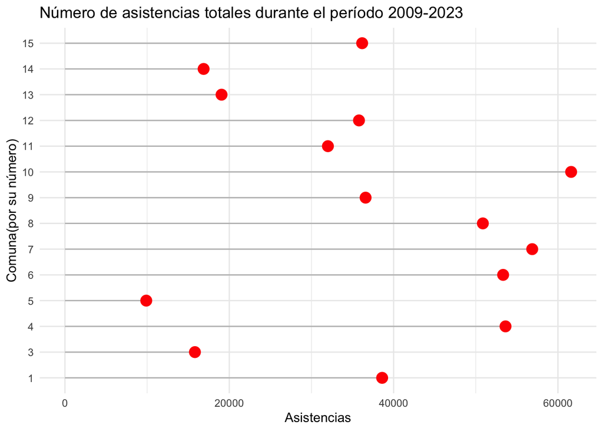

```r
ggplot(comuna_mayor, aes(x = reorder(comuna, -asist_totales), y = asist_totales)) +
  geom_segment(aes(x = comuna, xend = comuna, y = 0, yend = asist_totales), color = "grey") +
  geom_point(size = 4, color = "red") +
  labs(x = "Comuna(por su número)", y = "Asistencias", title = "Número de asistencias totales durante el período 2009-2023") +
  theme_minimal() +
  coord_flip()
```

Conclusiones: este gráfico muestra con claridad los primeros dos puestos de las asistencias aunque pierde consistencia en reflejar los cambios cuando la variable y tiene valores cercanos.

## Tabla estática

Si quisieramos reflejar los cambios más pequeños, podríamos usar una tabla estática como la que se detalla a continuación.

```r
library(knitr) #tablas estáticas
#install.packages(kableExtra)
library(kableExtra) #estética de tablas estáticas
kable(comuna_mayor,
      caption= "Número de asistencias totales durante el período 2009-2023",
      col.names = c("Comuna (por número)", "Asistencias totales")) %>%
  row_spec(0:14, #filas en las cuales queremos ajustar la estética del texto
              color = "black") %>% #color del texto
  kable_styling() %>%
  column_spec(1, #ubicación de la columna
              bold = TRUE, #letra "negrita"
              border_right = TRUE, #marcar línea de borde derecho
              background = "lightgrey") %>% #color del fondo del contenido de la columna
  row_spec(1:5, #fila a resaltar
           background = "#84a98c") #color para el fondo de la fila
```

Número de asistencias totales durante el período 2009-2023

| Comuna (por número) | Asistencias totales |
| --- | --- |
| 10 | 61607 |
| 7 | 56870 |
| 4 | 53620 |
| 6 | 53329 |
| 8 | 50862 |
| 1 | 38606 |
| 9 | 36591 |
| 15 | 36172 |
| 12 | 35786 |
| 11 | 32006 |
| 13 | 19060 |
| 14 | 16877 |
| 3 | 15819 |
| 5 | 9897 |

Se aprovecha para dar información de los 5 primeros puestos en asistencias mediante el resaltado de las casillas. La comuna 6 es el barrio de Caballito y la 8, Lugano.

## Promedio ITF de CABA

Sería interesante correlacionar la cantidad de actividad cultural gratuita con alguna variable que nos hable de la distribución de ingresos económicos de cada comuna. Como hipótesis preliminar podríamos suponer que la actividad gratuita debería estar concentrada en barrios con ingresos inferiores a la media ya que de lo contrario se estaría concentrando recursos gratuitos en barrios con un mayor poder adquisitivo. Podemos hacer uso del “Ingreso total familiar” (ITF) que es el que se obtiene sumando el ingreso individual de todos los miembros del hogar como un índice representativo del cual se tiene alcance por el siguiente link. Hacemos un promedio de los valores anuales desde el 2009-2023 para conservar el mismo tiempo de estudio. Fuente: https://www.estadisticaciudad.gob.ar/eyc/?p=82453

```r
promedio_itf_caba <- read_xlsx("data/Promedio_itf_caba.xlsx")
mod_promedio_itf_caba <- mutate(promedio_itf_caba, año=as.factor(año), comuna=as.factor(comuna), promedio_itf=as.integer(promedio_itf))
```

```r
dim(mod_promedio_itf_caba)
```

```
## [1] 210   4
```

Tenemos un nuevo data set con 210 registros de 4 variables.

```r
summary(mod_promedio_itf_caba)
```

```
##       año          comuna     promedio_itf        ...4
##  2009   : 15   1      : 14   Min.   :  2572   Length:210
##  2010   : 15   2      : 14   1st Qu.:  8490   Class :character
##  2011   : 15   3      : 14   Median : 22406   Mode  :character
##  2012   : 15   4      : 14   Mean   : 81730
##  2013   : 15   5      : 14   3rd Qu.: 63315
##  2014   : 15   6      : 14   Max.   :772489
##  (Other):120   (Other):126
```

```r
promedio_final <- promedio_itf_caba %>%
  group_by(comuna) %>%
  summarise( prom_general=mean(promedio_itf))
```

```r
mod_promedio_final <- promedio_final %>%
  arrange(desc(prom_general))
```

```r
head(mod_promedio_final, 15)
```

```
## # A tibble: 15 × 2
##    comuna prom_general
##     <dbl>        <dbl>
##  1     14      104917.
##  2     13      103748.
##  3     12       95776.
##  4      2       92043.
##  5      6       89945.
##  6     11       83170.
##  7      5       81424.
##  8      1       80373.
##  9      7       79492.
## 10     10       78316.
## 11     15       76085.
## 12      9       69961.
## 13      3       67036.
## 14      4       63562.
## 15      8       60110.
```

Luego de esta primera parte del código, damos con el ordenamiento de las comunas según su ingreso decreciente. La comuna 14 (Palermo) lidera el ranking.

## Gráfico de ingresos/asistencias.

En este punto quisiéramos representar gráficamente la interacción entre las dos variables que aparecieron en nuestro estudio hasta ahora. Sin embargo, sería conveniente distribuír a las comunas por subgrupos ordenados en cuanto a su ingreso por lo que se hecha mano de las noción de cuartil como herramienta de la estadística descriptiva. A continuación se detallan los pasos para llegar al gráfico.

```r
promedioxasistencia <- read_xlsx("data/promedioxasistencia.xlsx")
```

Hay una columna que tiene un na por ende

```r
promedioxasistencia <- na.omit(promedioxasistencia)
```

```r
str(promedioxasistencia)
```

```
## tibble [14 × 3] (S3: tbl_df/tbl/data.frame)
##  $ comuna             : num [1:14] 14 13 12 6 11 5 1 7 10 15 ...
##  $ promedio_itf       : chr [1:14] "104916.98" "103748.21" "95776.36" "89945.20" ...
##  $ asistencias_totales: num [1:14] 16877 19060 35786 53329 32006 ...
##  - attr(*, "na.action")= 'omit' Named int 4
##   ..- attr(*, "names")= chr "4"
```

```r
promedioxasistencia <- mutate(promedioxasistencia, promedio_itf=as.integer(promedio_itf), asistencias_totales=as.integer(asistencias_totales), comuna=as.character(comuna))
```

```r
str(promedioxasistencia)
```

```
## tibble [14 × 3] (S3: tbl_df/tbl/data.frame)
##  $ comuna             : chr [1:14] "14" "13" "12" "6" ...
##  $ promedio_itf       : int [1:14] 104916 103748 95776 89945 83169 81424 80372 79492 78315 76085 ...
##  $ asistencias_totales: int [1:14] 16877 19060 35786 53329 32006 9897 38606 56870 61607 36172 ...
##  - attr(*, "na.action")= 'omit' Named int 4
##   ..- attr(*, "names")= chr "4"
```

```r
quantile(promedioxasistencia$promedio_itf, probs = c(0.25,0.50,0.75))
```

```
##   25%   50%   75%
## 71492 79932 88251
```

Aplicar un case(when)

```r
promedioxasistencia <- mutate(promedioxasistencia,
                          q_itf=case_when(promedio_itf<=71492~"1er cuartil",
                                                      promedio_itf>71492 & promedio_itf<=79932~"2do cuartil",
                                                      promedio_itf>79932 & promedio_itf<=88251~"3er cuartil",
                                                      TRUE ~ "4to cuartil"))
```

Realizar gráfico de barras

```r
str(promedioxasistencia)
```

```
## tibble [14 × 4] (S3: tbl_df/tbl/data.frame)
##  $ comuna             : chr [1:14] "14" "13" "12" "6" ...
##  $ promedio_itf       : int [1:14] 104916 103748 95776 89945 83169 81424 80372 79492 78315 76085 ...
##  $ asistencias_totales: int [1:14] 16877 19060 35786 53329 32006 9897 38606 56870 61607 36172 ...
##  $ q_itf              : chr [1:14] "4to cuartil" "4to cuartil" "4to cuartil" "4to cuartil" ...
##  - attr(*, "na.action")= 'omit' Named int 4
##   ..- attr(*, "names")= chr "4"
```

[figure not shown]

```r
ggplot(promedioxasistencia)+
  geom_bar(aes(x=comuna, weight=asistencias_totales, fill=q_itf)) +
  labs(title="Asistencias según promedio de ingresos",
       subtitle="de 2009 a 2018",
       fill="Cuartil de ingresos",
       x="Comuna",
       y="Asistencias totales",
       caption="Fuente: Ministerio de Cultura de Caba") +
  scale_fill_manual(values = c("goldenrod2", "indianred2","grey","blue")) +
  theme_light()
```

De los primeros 5, solo la comuna 6 (barrio de caballito) está en el cuartil superior de ingresos. Probablemente esto se deba a la cantidad de gente que esté barrio tiene o a la alta accesibilidad con la que cuenta por estar en el centro de la ciudad.

## Relación con el número de habitantes de cada comuna.

De la conclusión del gráfico anterior se abre otra pregunta que podríamos intentar contestar: ¿acaso guarda relación la cantidad de asistentes con la población de cada comuna?. Para ello contamos con los datos obtenidos del siguiente link. Se detallan los pasos para llegar a la representación gráfica de esta cuestión. Fuente: https://www.estadisticaciudad.gob.ar/eyc/?p=79970

```r
poblacionxpromedioxasistencia <- read_xlsx("data/Copia de promedioxasistencia.xlsx")
```

```r
poblacionxpromedioxasistencia <- mutate(poblacionxpromedioxasistencia, comuna=as.factor(comuna), promedio_itf=as.integer(promedio_itf), asistencias_totales=as.integer(asistencias_totales), poblacion_total=as.integer(poblacion_total))
```

```r
str(poblacionxpromedioxasistencia)
```

```
## tibble [15 × 4] (S3: tbl_df/tbl/data.frame)
##  $ comuna             : Factor w/ 15 levels "1","2","3","4",..: 14 13 12 2 6 11 5 1 7 10 ...
##  $ promedio_itf       : int [1:15] 104916 103748 95776 92042 89945 83169 81424 80372 79492 78315 ...
##  $ asistencias_totales: int [1:15] 16877 19060 35786 NA 53329 32006 9897 38606 56870 61607 ...
##  $ poblacion_total    : int [1:15] 227315 236723 215442 149345 185964 190195 187991 258922 242828 170859 ...
```

```r
poblacionxpromedioxasistencia <- mutate(poblacionxpromedioxasistencia,
                          q_itf=case_when(promedio_itf<=71492~"1er cuartil",
                                                      promedio_itf>71492 & promedio_itf<=79932~"2do cuartil",
                                                      promedio_itf>79932 & promedio_itf<=88251~"3er cuartil",
                                                      TRUE ~ "4to cuartil"))
```

Dividir la población en dos según el promedio de habitantes.

```r
mean(poblacionxpromedioxasistencia$poblacion_total)
```

```
## [1] 205698.9
```

Aplicar un if(else) para separar los grupos en 2

```r
poblacionxpromedioxasistencia <- mutate(poblacionxpromedioxasistencia,
                          media_poblacional=if_else(poblacion_total<=205698.9, "Menos población", "Más población"))
```

Hacer un gráfico doble facetado(filtros por media poblacional y de ingreso)

[figure not shown]

```r
ggplot(poblacionxpromedioxasistencia)+
  geom_bar(aes(x=comuna, weight=asistencias_totales, fill=q_itf)) +
  labs(title="Asistencias según promedio de ingresos",
       subtitle="de 2009 a 2018",
       fill="Cuartil de ingresos",
       x="Comunas de CABA",
       y="Asistencias totales a actividades culturales de centros públicos",
       caption="Fuente: IdecBA") +
  scale_fill_manual(values = c("goldenrod2", "indianred2","grey","blue")) +
  theme_light()+
    facet_wrap(~media_poblacional)
```

Se ve que este gráfica hace coexistir la división por ingresos y la división por una variable binaria que discrimina a las comunas según estén por arriba o por debajo de la media poblacional para CABA durante el período 2009-2023. Caballito sigue siendo un valor llamativo ya que está en el podio de asistencias a centros culturales barriales siendo uno de los barrios con menos población y con mayor ingreso. Se sostiene la pregunta sobre si los asistentes vienen de barrios aledaños que intentaremos representar gráficamente.

## Evolución de las actividades a traves de los años

Otra pregunta pertinente sería cuantas actividades realizaron en total todos los centros culturales por año. Esto nos daría una pista sobre la financiación de las mismas por ejemplo y podría ser interesante observar si se producen cambios drásticos de un año a otro (relativo a crisis económicas, cambios de gobierno y otras explicaciones posibles.)

```r
actividadesxaño <- group_by(actividades_culturales, Año) %>%
  summarise(actividades_totales=sum(actividades))
```

```r
head(actividadesxaño)
```

```
## # A tibble: 6 × 2
##     Año actividades_totales
##   <dbl>               <dbl>
## 1  2009               1167
## 2  2010               1222
## 3  2011               1187
## 4  2012               1167
## 5  2013               1172
## 6  2014               1219.
```

```r
# Libraries
library(tidyverse)
library(babynames)
library(viridis)
```

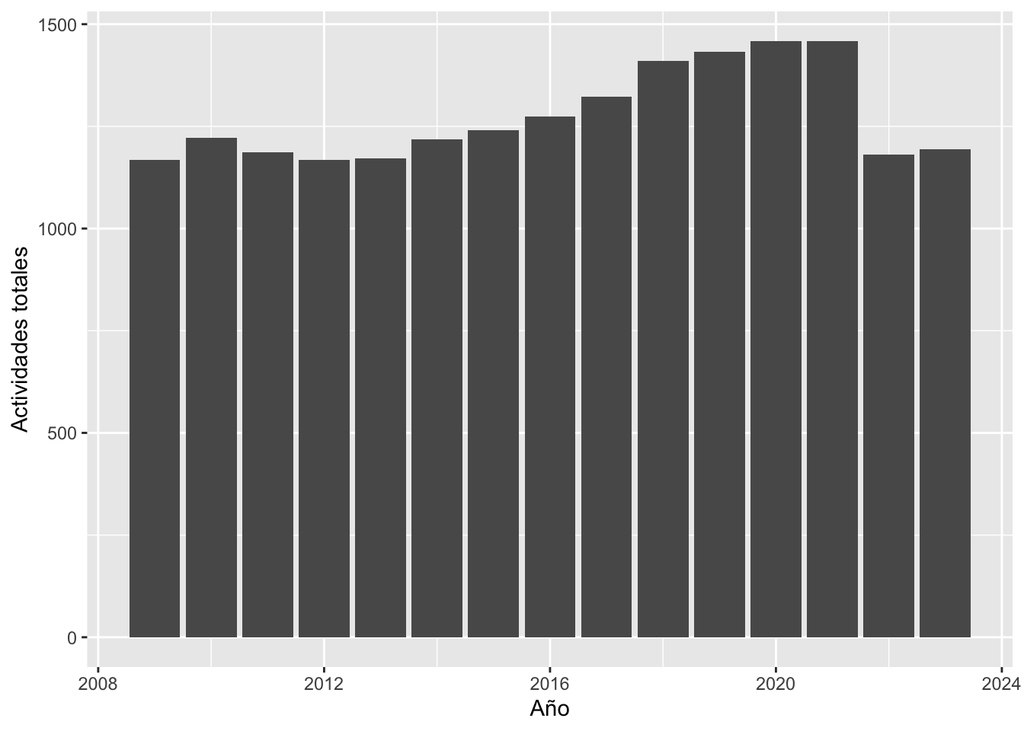

```r
  ggplot(actividadesxaño) +
    aes(x=Año, y=actividades_totales) +
    geom_bar(stat="identity", position="dodge") +
    scale_fill_viridis(discrete=TRUE, name="") +
    ylab("Actividades totales")
```

## Evolución de la asistencia a traves de los años.

Una pregunta anexa sería observar como evolucionó la asistencia con el correr de los años.

```r
asistenciasxaño <- group_by(actividades_culturales, Año) %>%
  summarise(asistencias_totales=sum(asistentes))
```

[figure not shown]

```r
  ggplot(asistenciasxaño) +
    aes(x=Año, y=asistencias_totales) +
    geom_bar(stat="identity", position="dodge") +
    scale_fill_viridis(discrete=TRUE, name="") +
    ylab("Actividades totales")
```

Se observa el acomopañamiento de la tendencia del gráfico anterior.

## Cantidad de establecimientos por barrio.

Otra pregunta sería qué barrio tiene la mayor cantidad de centros culturales.

```r
nestablecimientos <- actividades_culturales %>%
  group_by(barrio) %>%
  count(barrio)
```

```r
nestablecimientos2 <- mutate(nestablecimientos, n=n/15) %>%
   arrange(desc(n))
```

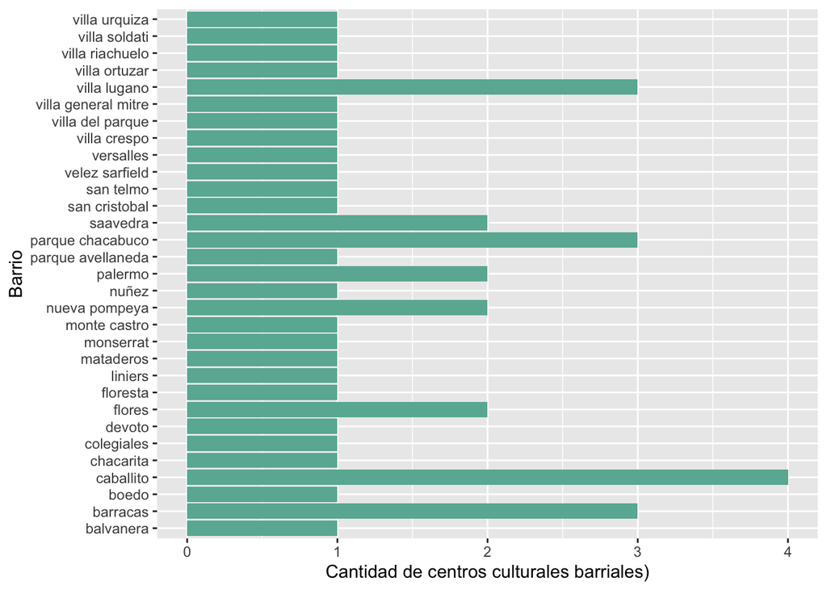

```r
nestablecimientos2 %>%
  ggplot( aes(x=barrio, y=n) ) +
    geom_bar(stat="identity", fill="#69b3a2") +
    coord_flip() +
   xlab("Barrio") +
    ylab("Cantidad de centros culturales barriales)")
```

El siguiente gráfico muestra la cantidad de centros por barrio. Caballito es el barrio con más centros culturales con el record de 4.

## Record de asistencias a una actividad.

Por otro lado, sería interesante saber qué actividad tuvo la mayor participación durante estos años.

```r
which.max(actividades_culturales$asistentes)
```

```
## [1] 119
```

En 2021 el centro cultural Versalles tuvo el record histórico de asistencias con 4596 personas

## Record de cantidad de actividades en un año.

```r
which.max(actividades_culturales$actividades)
```

```
## [1] 144
```

El 2020, el centro cultural El Eternauta del barrio de caballito tuvo el record histórico de actividades con un número de 73.

## Mapa. Para georeferenciar la concentración de la asistencias.

Por último, sería interesante ver (mediante la utilización de un mapa coroléptico) si las asistencias se concentran en algún sector puntual de la geografía de CABA. Para eso hay que localizar las asistencias por comunas mediante una escala cromática. Comencemos por poner a punto el data set y realizar el gráfico.

Cambiar los nombres del data frame

```r
comuna_mayor$comuna <- paste("Comuna", comuna_mayor$comuna)
```

```r
datos_amba <- partidos_amba %>%
  filter(provincia=="CABA") %>%
  group_by(nombre)
```

```r
datos_amba <- datos_amba[-1, ]
```

```r
datos_amba <- left_join(datos_amba, comuna_mayor, by=c("nombre"="comuna"))
```

Ahora el df “datos_amba” cuenta con las asistencias totales

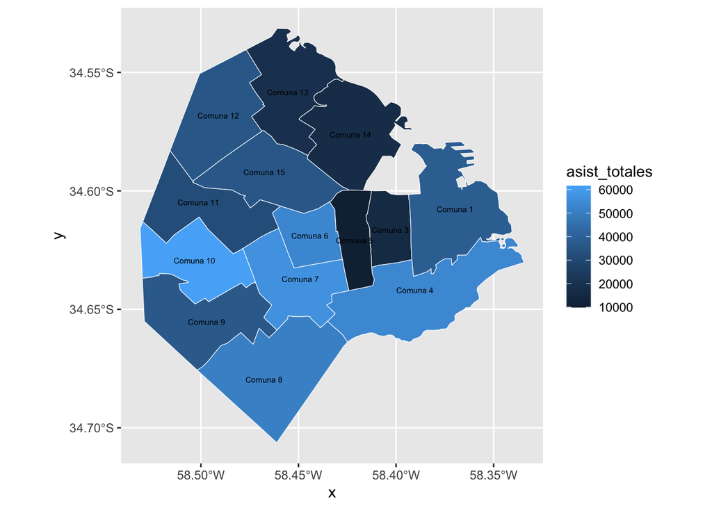

```r
ggplot(datos_amba) +
  geom_sf(color = "white", aes(fill = asist_totales)) +
  geom_sf_text(aes(label = nombre), size = 2)
```

## Conclusiones.

Este trabajo realiza un análisis exploratorio de datos públicos sobre los centros cultruales barriales de la Ciudad Autónoma de Buenos Aires. Los mismos tienen actividades que se intuyen ligadas a los vaivenes del gasto público de los gobiernos de turno (como se muestra en las variaciones de las asistencias/cantidad de actividades por año) pero en cuya planificación geográfica hay varias variables que se pueden tener en cuenta. Entre ellas están el ingreso económico de cada comuna, su población total y su ubicación geográfica. Las finalidades de este trabajo son exploratorias por lo que no se han planteado hipótesis que puedan ser corroborados sino preguntas puntuales que pudieron ser contestadas con datos de fuentes accesibles al público.